# Spectral_Similarity_Patterns

Degnan, David J

2023-06-30

## Read all files

Here is a trelliscope display of the results:

[interactive chart not shown]

## Correlation Score

#### Pearson Correlation: Max Score

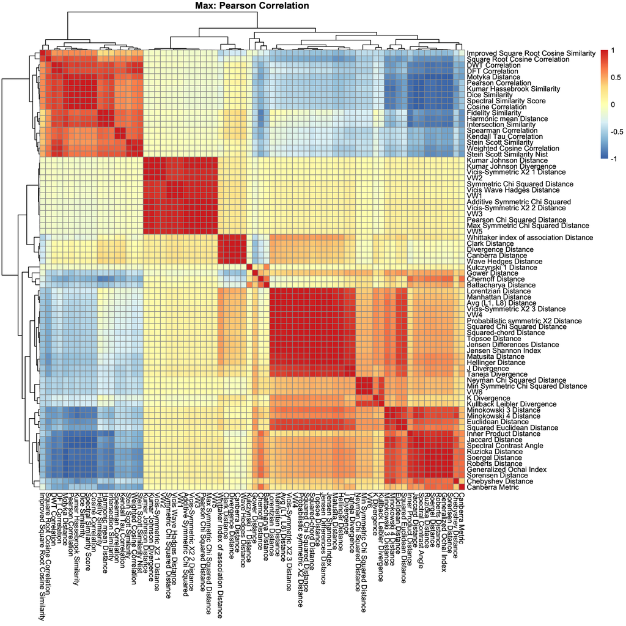

There are 4 distinct clusters of scores using the max scaled data and a Pearson correlation.

#### Pearson Correlation: Sum Score

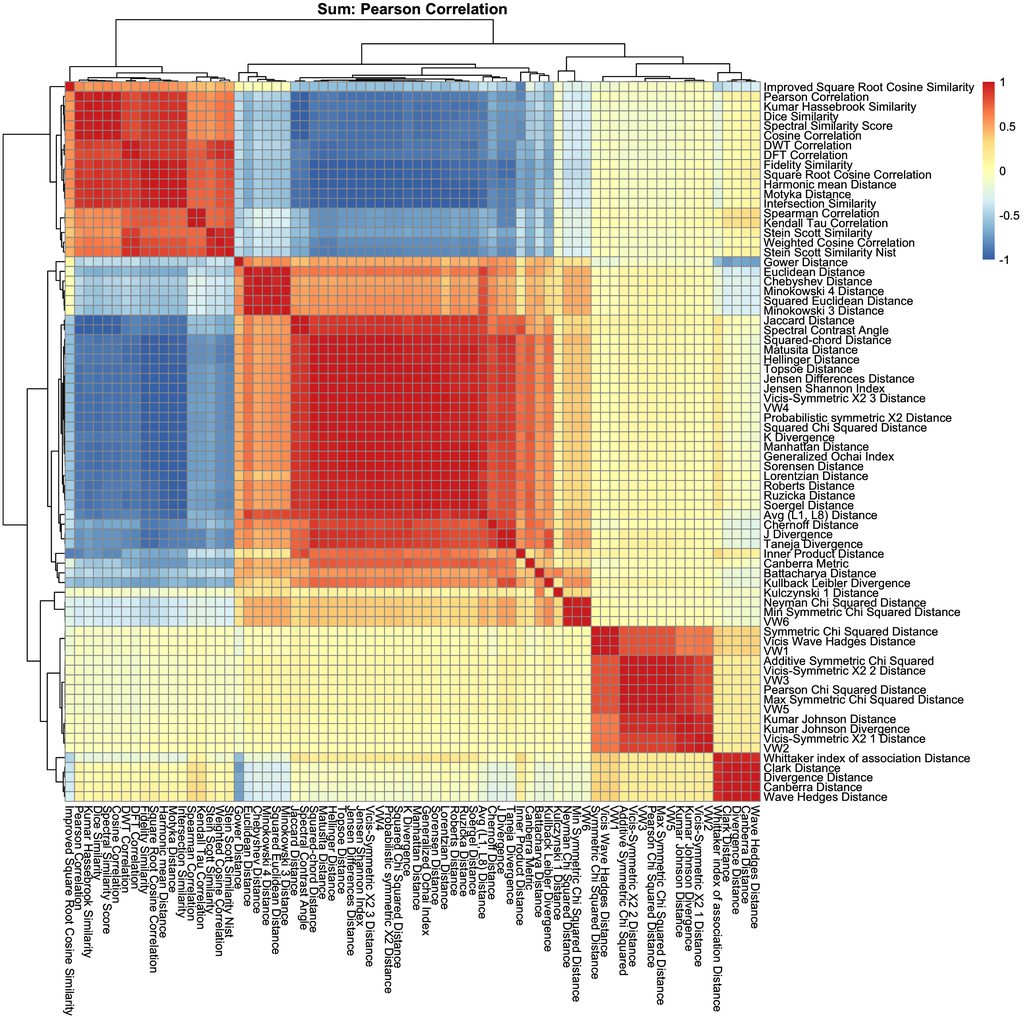

There are 4 distinct clusters of scores using the sum scaled data and a Pearson correlation. These are the same clusters as in the max scaled data.0

## Add T Statistic & Distributional Properties

Here, we are only interested in a t-statistic to measure the separation of score distributions between true positives and true negatives.

|  | Score | Family | Type | TheoreticalBounds | TheoreticalBounds2 | SumCluster | MaxCluster | TStatisticSum | TStatisticMax | Sum_ScoreMin | Sum_ScoreMedian | Sum_ScoreMax | Max_ScoreMin | Max_ScoreMedian | Max_ScoreMax | Overlap_Sum | Overlap_Max |
| --- | --- | --- | --- | --- | --- | --- | --- | --- | --- | --- | --- | --- | --- | --- | --- | --- | --- |
| 1 | Additive Symmetric Chi Squared | Chi Squared | Distance | Left | [0, Inf) | 3 | 2 | -52.59717197 | -75.29661935 | 204480027 | 290797000000000 | 3.07758e+17 | 568152911.3000001 | 1592330000000000 | 8.63901e+17 | 0.0917989 | 0.09216966 |
| 2 | Avg (L1, L8) Distance | Combination | Distance | Left | [0, Inf) | 2 | 4 | -432.7986793 | -398.1508614 | 0.0116 | 0.9695 | 1.5 | 0.0258 | 3.9008 | 20.0035 | 0.01609076 | 0.03010529 |
| 3 | Battacharya Distance | Fidelity | Distance | Not | (-Inf, Inf) | 2 | 4 | -408.8793964 | -304.6260687 | 0.0023 | 1.1798 | 15.8811 | -2.5572 | -0.21 | 14.9177 | 0.01394038 | 0.06102625 |
| 4 | Canberra Distance | L1 Distance | Distance | Left | [0, Inf) | 4 | 3 | -97.58964857000001 | -91.59044588 | 7.4332 | 107.6117 | 465.2669 | 7.8574 | 107.6462 | 467.3437 | 0.25856444 | 0.2596767 |
| 5 | Canberra Metric | L1 Metric | Similarity | Both | [0, 1] | 2 | 4 | -219.4945438 | -219.468668 | 0.1499 | 0.9354 | 1 | 0.1553 | 0.9351 | 1 | 0.03915171 | 0.03514756 |
| 6 | Chebyshev Distance | LP Distance | Similarity | Both | [0, 1] | 2 | 4 | -286.3234113 | -256.7701977 | 0.002 | 0.2753 | 1 | 0.0043 | 1 | 1 | 0.08638588 | 0.06792229 |
| 7 | Chernoff Distance | Fidelity | Distance | Not | (-Inf, Inf) | 2 | 4 | -460.2479519 | -267.0307383 | -0.4292 | 0.8247 | 3.3161 | -3.1507 | -0.502 | 2.8025 | 0.02550793 | 0.14689307 |
| 8 | Clark Distance | Chi Squared | Distance | Left | [0, Inf) | 4 | 3 | -110.5048735 | -108.1820138 | 2.1477 | 10.2154 | 21.4232 | 2.2355 | 10.2188 | 21.3376 | 0.23491028 | 0.23987839 |
| 9 | Cosine Correlation | Inner Product | Similarity | Both | [0, 1] | 1 | 1 | 512.3804392999999 | 512.3804392999999 | 0 | 0.214 | 1 | 0 | 0.214 | 1 | 0.02476642 | 0.02476642 |
| 10 | DFT Correlation | Inner Product | Similarity | Both | [-1, 1] | 1 | 1 | 578.9360778 | 578.9360778 | 0 | 0.1964 | 0.9983000000000001 | 0 | 0.1964 | 0.9983000000000001 | 0.01305057 | 0.01305057 |

[output cut: 64 more lines]

Descriptions:

**Score:** The tested spectral similarity score

**Family:** The family of metrics the score comes from

**Type:** Indicates whether the score is a similarity (ranges from 0-1 or -1 to 1 fore directionality) or a distance (typically unbounded on one or both sides)

**Theoretical Bounds:** The bounds written as a categorical variable

**Theoretical Bounds 2:** The bounds written in bracket format where a square bracket is inclusive and a parentheses is not inclusive.

**SumCluster:** The cluster number the score falls into for the sum data

**MaxCluster:** The cluster number the score falls into for the max data

**TStatisticSum:** The t-statistic between the true positives and true negatives for a score in the sum data

**TStatisticMax:** The t-statistic between the true positives and true negatives for a score in the max data

**Sum_ScoreMin:** The score’s minimum value in the sum dataset

**Sum_ScoreMedian:** The score’s median value in the sum dataset

**Sum_ScoreMax:** The score’s maximum value in the sum dataset

**Max_ScoreMin:** The score’s minimum value in the max dataset

**Max_ScoreMedian:** The score’s median value in the max dataset

**Max_ScoreMax:** The score’s maximum value in the max dataset

**Overlap_Sum:** The overlap score (which is the propotion of true positives that overlap with the true negative/unknown distributions) for the sum dataset

**Overlap_Max:** The overlap score (which is the proportion of true positives that overlap with the true negative/unknown distributions) for the max dataset

## Random Forest

Data was split into 75% training and 25% testing datasets. Hyperparameters were fine tuned using the recipes and workflowsets R packages with leave one out 10-fold cross-validation repeated 5 times each for a total of 50 times. Random forest models were fit using the ranger R package.

#### Sum Model

The best fit model was:

```
## # A tibble: 1 × 3
##    mtry trees .config
##   <int> <int> <chr>
## 1     3   399 Preprocessor1_Model07
```

The testing dataset yielded the following results:

```
## # A tibble: 17 × 6
##    pred_class .pred_1 .pred_2 .pred_3 .pred_4 Cluster
##    <fct>        <dbl>   <dbl>   <dbl>   <dbl> <fct>
##  1 1          0.853   0.0899  0.0103  0.0472  1
##  2 1          0.957   0.0415  0       0.00168 1
##  3 1          0.441   0.146   0.175   0.238   1
##  4 1          0.959   0.0380  0       0.00325 1
##  5 2          0.131   0.861   0       0.00787 2
##  6 2          0.0413  0.952   0       0.00657 2
##  7 2          0.151   0.831   0       0.0180  2
##  8 2          0.270   0.728   0       0.00262 2
##  9 2          0.298   0.700   0       0.00262 2
## 10 2          0.116   0.608   0.0250  0.250   2
## 11 2          0.0413  0.952   0       0.00657 2
## 12 2          0.0177  0.960   0.00276 0.0196  2
## 13 2          0.0244  0.961   0       0.0145  2
## 14 3          0.00499 0.0210  0.939   0.0348  3
## 15 3          0.00286 0.0114  0.946   0.0399  3
## 16 3          0.00430 0.00901 0.953   0.0338  3
## 17 4          0.0767  0.153   0.116   0.654   4
```

Description:

```
## # A tibble: 1 × 3
##   .metric  .estimator .estimate
##   <chr>    <chr>          <dbl>
## 1 accuracy multiclass         1
```

Description:

```
## # A tibble: 8 × 2
##   Variable          Importance
##   <chr>                  <dbl>
## 1 TStatisticSum        100
## 2 Overlap_Sum           36.8
## 3 Median                35.1
## 4 Min                   16.3
## 5 TheoreticalBounds     15.8
## 6 Type                  11.3
## 7 Family                11.2
## 8 Max                    0.429
```

#### Max Model

The best fit model was:

```
## # A tibble: 1 × 3
##    mtry trees .config
##   <int> <int> <chr>
## 1     5  1973 Preprocessor1_Model02
```

The testing dataset yielded the following results:

```
## # A tibble: 17 × 6
##    pred_class  .pred_1   .pred_2   .pred_3 .pred_4 Cluster
##    <fct>         <dbl>     <dbl>     <dbl>   <dbl> <fct>
##  1 1          0.989    0.0000507 0.00297   0.00822 1
##  2 1          0.983    0.0000507 0.00630   0.0102  1
##  3 1          0.990    0         0.00247   0.00735 1
##  4 1          0.885    0.0102    0.0515    0.0532  1
##  5 2          0.000893 0.969     0.0264    0.00337 2
##  6 2          0.00242  0.976     0.0174    0.00402 2
##  7 2          0.000914 0.979     0.0166    0.00345 2
##  8 3          0.0528   0.110     0.688     0.149   3
##  9 4          0.00850  0         0.000190  0.991   4
## 10 4          0.0112   0         0.0000634 0.989   4
## 11 4          0.00266  0         0.0476    0.950   4
## 12 4          0.000523 0         0.0472    0.952   4
## 13 4          0.00377  0         0.0149    0.981   4
## 14 4          0.000523 0         0.0472    0.952   4
## 15 4          0.000371 0.0000507 0.000361  0.999   4
## 16 4          0.000523 0         0.0472    0.952   4
## 17 4          0.000659 0         0.00827   0.991   4
```

Description:

```
## # A tibble: 1 × 3
##   .metric  .estimator .estimate
##   <chr>    <chr>          <dbl>
## 1 accuracy multiclass         1
```

Description:

```
## # A tibble: 8 × 2
##   Variable          Importance
##   <chr>                  <dbl>
## 1 TStatisticMax         100
## 2 Overlap_Max            20.9
## 3 Median                 18.9
## 4 Max                    18.0
## 5 TheoreticalBounds       5.38
## 6 Min                     5.32
## 7 Family                  3.13
## 8 Type                    1.39
```

## Comparison

Given the high performance of both models, the most important variables for defining clusters are:

```
##            Variable Sum Importance Max Importance
## 1        TStatistic    100.0000000     100.000000
## 2           Overlap     36.7693648      20.916578
## 3            Median     35.1091359      18.927213
## 4               Min     16.3041220       5.322523
## 5 TheoreticalBounds     15.8184883       5.380536
## 6              Type     11.2621223       1.390213
## 7            Family     11.1554183       3.127905
## 8               Max      0.4290812      17.955808
```

# Cluster Descriptions

**Sum Data:**

|  | Cluster | MeanTStat | MeanOverlap | MeanMedian | MeanMin | MeanMax | TheoreticalBounds_Left | TheoreticalBounds_Right | TheoreticalBounds_Both | TheoreticalBounds_None | Type_Distance | Type_Similarity | Chi Squared | Combination | Combined RI | Correlative | Fidelity | Inner Product | Intersection | L1 Distance | L1 Metric | LP Distance | Shannon Entropy | Vicis Wave Hedges |
| --- | --- | --- | --- | --- | --- | --- | --- | --- | --- | --- | --- | --- | --- | --- | --- | --- | --- | --- | --- | --- | --- | --- | --- | --- |
| 1 | 1 | 484.4421487055556 | 0.0218457 | 0.1255833333333334 | -0.1303166666666667 | 0.9179333333333334 | 3 | 0 | 15 | 0 | 4 | 14 | 0 | 0 | 1 | 3 | 1 | 11 | 2 | 0 | 0 | 0 | 0 | 0 |
| 2 | 2 | -414.3860754934211 | 0.02620456289473684 | 94266578949.9326 | 0.01825526315789474 | 23991473684215.17 | 27 | 1 | 8 | 2 | 30 | 8 | 6 | 2 | 0 | 0 | 5 | 4 | 0 | 6 | 1 | 6 | 6 | 2 |
| 3 | 3 | -44.93360163076923 | 0.1420048123076923 | 3.092307698538472e+29 | 1.016923079477017e+21 | 5.815384617153845e+34 | 13 | 0 | 0 | 0 | 13 | 0 | 6 | 1 | 0 | 0 | 0 | 0 | 0 | 0 | 0 | 0 | 1 | 5 |
| 4 | 4 | -151.719613124 | 0.213376838 | 106.00152 | 5.62534 | 462.86202 | 5 | 0 | 0 | 0 | 5 | 0 | 2 | 0 | 0 | 0 | 0 | 0 | 1 | 1 | 0 | 0 | 1 | 0 |

The “best” clusters are 1 and 2, just where Cluster 1 has higher scores for True Positives than True Negatives/Unknowns, and Cluster 2 has lower scores for True Positives than True Negatives/Unknown.

**Cluster 1 Diagnostics:** Highest T Stat, Lowest Overlap Score, majority of scores are bound at both ends and similarity metrics, most scores are inner product, correlative, or intersection family

**Cluster 2 Diagnostics:** Lowest T Stat, 2nd best Overlap Score, mostly bound to the left, primarily distance metrics. No obvious family patterns.

**Cluster 3 Diagnostics:** 3rd best Overlap score. All left-bound distance metrics. Mostly the Chi Squared and Vicis Wave Hedges families.

**Max Data:**

|  | Cluster | MeanTStat | MeanOverlap | MeanMedian | MeanMin | MeanMax | TheoreticalBounds_Left | TheoreticalBounds_Right | TheoreticalBounds_Both | TheoreticalBounds_None | Type_Distance | Type_Similarity | Chi Squared | Combination | Combined RI | Correlative | Fidelity | Inner Product | Intersection | L1 Distance | L1 Metric | LP Distance | Shannon Entropy | Vicis Wave Hedges |
| --- | --- | --- | --- | --- | --- | --- | --- | --- | --- | --- | --- | --- | --- | --- | --- | --- | --- | --- | --- | --- | --- | --- | --- | --- |
| 1 | 1 | 413.9582078888889 | 0.02786016777777778 | 0.2388333333333333 | -0.1303166666666667 | 2.8028 | 3 | 0 | 15 | 0 | 4 | 14 | 0 | 0 | 1 | 3 | 1 | 11 | 2 | 0 | 0 | 0 | 0 | 0 |
| 2 | 2 | -410.5957227597368 | 0.03450361815789474 | 550863421061.7018 | -0.349971052631579 | 10769492105325.73 | 27 | 1 | 8 | 2 | 30 | 8 | 6 | 2 | 0 | 0 | 5 | 4 | 0 | 6 | 1 | 6 | 6 | 2 |
| 3 | 3 | -68.59687410461538 | 0.1365632738461539 | 4.092307728153864e+29 | 8.738461602047685e+20 | 1.112307693846154e+34 | 13 | 0 | 0 | 0 | 13 | 0 | 6 | 1 | 0 | 0 | 0 | 0 | 0 | 0 | 0 | 0 | 1 | 5 |
| 4 | 4 | -147.916432816 | 0.215423402 | 106.03862 | 5.94456 | 464.38002 | 5 | 0 | 0 | 0 | 5 | 0 | 2 | 0 | 0 | 0 | 0 | 0 | 1 | 1 | 0 | 0 | 1 | 0 |

Given the overlap score difference, we recommend using the sum method over the max method.

Cluster patterns are the same as above.